# Mixed Models

Behavioral Data Science

## Packages

We will need the following:

```r
install.packages(c("lme4", "lmerTest", "merTools"))
```

## Terminology

While the specifics of each model you have learned to this point might take some time to get our heads all the way around, the terminology has largely been pretty clear – no more. You will hear “mixed models”, “mixed effects models”, “hierarchical linear models”, “nested models”, and/or “multilevel models”; these are all slight variations on a common theme. For the sake of our work here, we will keep it at mixed models. Within our mixed model, we have an additional source of cloudiness: fixed and random effects. The random effects don’t pose much of an issue (we will define it later), but fixed effects have 4 different definitions depending upon whom you ask. For the sake of simplicity (again), we are going to consider fixed effects as an effect on the individual unit of analysis. This will all start to make sense once we take a look at the models.

## Standard Linear Model

For the sake of conceptual grounding, let’s go back to our standard linear model:

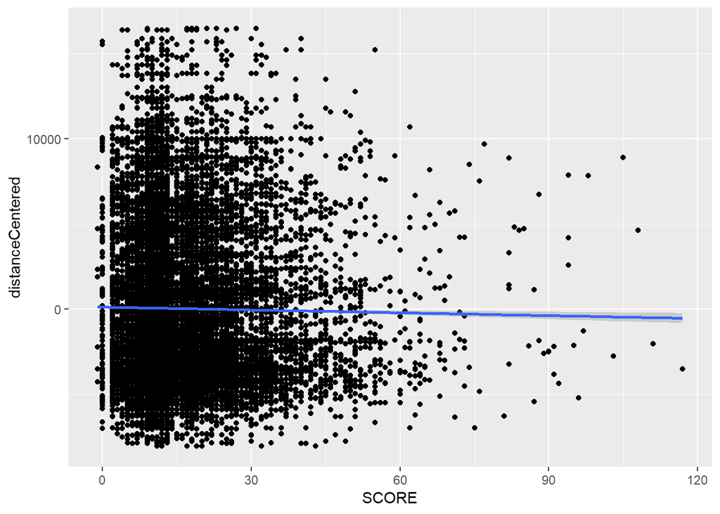

```r
library(dplyr)

library(ggplot2)

healthData = readr::read_csv("https://www.nd.edu/~sberry5/data/healthViolationsDistances.csv")

healthData = healthData %>%
  mutate(BORO = as.factor(.$BORO),
         cuisine = as.factor(.$`CUISINE DESCRIPTION`),
         distanceCentered = dohDistanceMeter - mean(dohDistanceMeter))

lmTest = lm(SCORE ~ distanceCentered, data = healthData)

ggplot(healthData, aes(SCORE, distanceCentered)) +
  geom_point() +
  geom_smooth(method = "lm")
```

```r
summary(lmTest)
```

```
Call:
lm(formula = SCORE ~ distanceCentered, data = healthData)

Residuals:
    Min      1Q  Median      3Q     Max
-22.249  -9.312  -3.146   5.755  95.787

Coefficients:
                   Estimate Std. Error t value Pr(>|t|)
(Intercept)       2.104e+01  6.306e-02 333.615  < 2e-16 ***
distanceCentered -4.905e-05  1.354e-05  -3.622 0.000293 ***
---
Signif. codes:  0 '***' 0.001 '**' 0.01 '*' 0.05 '.' 0.1 ' ' 1

Residual standard error: 13.8 on 47907 degrees of freedom
Multiple R-squared:  0.0002737, Adjusted R-squared:  0.0002529
F-statistic: 13.12 on 1 and 47907 DF,  p-value: 0.000293
```

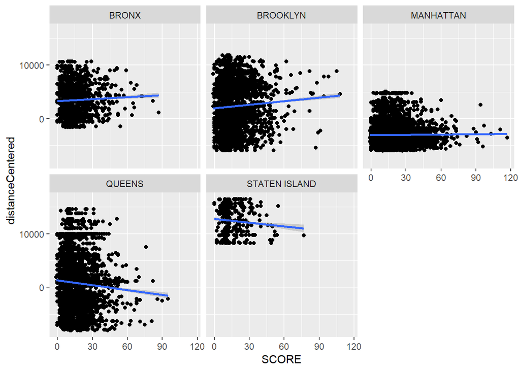

```r
ggplot(healthData, aes(SCORE, distanceCentered, group = BORO)) +
  geom_point() +
  geom_smooth(method = "lm") +
  facet_wrap( ~ BORO)
```

### Why Mixed Models

When we have repeated samples/measurement, mixed models will not overfit or underfit. They don’t get bogged down by large groups and the smaller groups do not get buried by the larger groups.

In linear models, you likely learned about balance in *t*-tests; mixed models will attenuate the effects of group imbalance.

## Random Intercepts Model

Let’s include borough in our model. We are not going to add it as another predictor, but we are going to include it as another level to our model. The **lme4** package will make this very easy:

```r
library(lme4)

riMod = lmer(SCORE ~ distanceCentered + (1|BORO), data = healthData)
```

Before we look at the summary for this model, let’s get an idea about what is happening in the syntax. The first part of our formula should look familiar – these are the global estimates (fixed effects) within our model and will behave exactly the same as our standard linear model.

The next part in the parentheses is how we denote our random effect. Whenever you see a 1 included in a formula interface, we can be pretty comfortable that it is in reference to a intercept. The *|* specifies a grouping. With that information, we might be able to guess that we are specifying a random intercept for each borough.

We should probably check out the summary:

```r
summary(riMod)
```

```
Linear mixed model fit by REML ['lmerMod']
Formula: SCORE ~ distanceCentered + (1 | BORO)
   Data: healthData

REML criterion at convergence: 387368.3

Scaled residuals:
    Min      1Q  Median      3Q     Max
-1.6457 -0.7010 -0.2296  0.4065  6.9165

Random effects:
 Groups   Name        Variance Std.Dev.
 BORO     (Intercept)   0.9879  0.9939
 Residual             189.9733 13.7831
Number of obs: 47909, groups:  BORO, 5

Fixed effects:
                  Estimate Std. Error t value
(Intercept)      2.076e+01  4.592e-01  45.204
distanceCentered 1.078e-05  1.761e-05   0.612

Correlation of Fixed Effects:
            (Intr)
distncCntrd -0.111
fit warnings:
Some predictor variables are on very different scales: consider rescaling
```

We have our standard output and we can see that our coefficients have changed from our standard linear model – this change is purely due to the severe imbalance between our groups:

```r
healthData %>%
  group_by(BORO) %>%
  summarize(n())
```

```
# A tibble: 5 x 2
  BORO          `n()`
  <fct>         <int>
1 BRONX          4083
2 BROOKLYN      11079
3 MANHATTAN     20250
4 QUEENS        11558
5 STATEN ISLAND   939
```

When groups are largely balanced, we would find that our coefficients would be the same (or very close to it).

What should almost always change is our standard errors – by integrating information about the groups, we are getting a better sense of how much uncertainty our model contains at the global average level.

We also see some additional information – this is for our random effects. The standard deviation is telling us how much the score moves around based upon borough after getting the information from our fixed effects (i.e., the health score can move around nearly 1 whole point from boro alone). We can compare the standard deviation for BORO to the coefficient for distanceCentered – Borough is contributing to more variability within Scores than distance. We can also add the variance components and divide by the random effects variance to get its variance account for.

```r
.9879 / (.9879 + 189.9733)
```

```
[1] 0.005173302
```

So while it might be doing more than what distance does, borough is not accounting for too much variance.

We can also plot simulated random effect ranges for each of the random effect groups. We want to pay attention to those that are highlighed with black (i.e., the range does not cross the red line at 0).

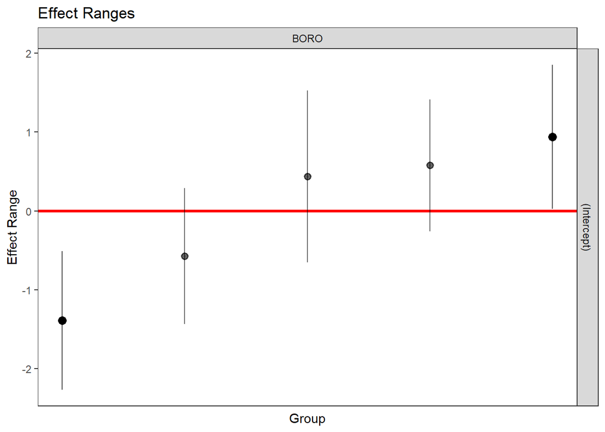

```r
library(merTools)

plotREsim(REsim(riMod))
```

```r
levels(healthData$BORO)
```

```
[1] "BRONX"         "BROOKLYN"      "MANHATTAN"     "QUEENS"
[5] "STATEN ISLAND"
```

In examining the plot, we see that the random effect ranges for the Bronx and Staten Island have significant effects on health score.

Going back to the output, did you notice anything missing: *p*-values! Estimating *p*-values in a mixed model is exceedingly difficult because of varying group sizes, complete sample *n*, and how those relate to reference distributions. If you need something that will help, you can get confidence intervals in the same way that you would anything else:

```r
confint(riMod)
```

```
                         2.5 %       97.5 %
.sig01            5.025929e-01 1.961607e+00
.sigma            1.369612e+01 1.387068e+01
(Intercept)       1.978061e+01 2.174178e+01
distanceCentered -2.375822e-05 4.505094e-05
```

If you *really* want to see *p*-values, you can get them easily:

```r
riModP = lmerTest::lmer(SCORE ~ distanceCentered + (1|BORO), data = healthData)

summary(riModP)
```

```
Linear mixed model fit by REML. t-tests use Satterthwaite's method [
lmerModLmerTest]
Formula: SCORE ~ distanceCentered + (1 | BORO)
   Data: healthData

REML criterion at convergence: 387368.3

Scaled residuals:
    Min      1Q  Median      3Q     Max
-1.6457 -0.7010 -0.2296  0.4065  6.9165

Random effects:
 Groups   Name        Variance Std.Dev.
 BORO     (Intercept)   0.9879  0.9939
 Residual             189.9733 13.7831
Number of obs: 47909, groups:  BORO, 5

Fixed effects:
                  Estimate Std. Error        df t value Pr(>|t|)
(Intercept)      2.076e+01  4.592e-01 4.133e+00  45.204 9.96e-07 ***
distanceCentered 1.078e-05  1.761e-05 3.455e+03   0.612     0.54
---
Signif. codes:  0 '***' 0.001 '**' 0.01 '*' 0.05 '.' 0.1 ' ' 1

Correlation of Fixed Effects:
            (Intr)
distncCntrd -0.111
fit warnings:
Some predictor variables are on very different scales: consider rescaling
```

**NOTE:** I would never load the lmerTest package, but would attach with colons! If you load it, you will find that it masks things from lme4 that you don’t want to have masked (i.e., lmer) and they are not equivalent objects!

Getting predicted values from our mixed model is no different then getting them from any other model:

```r
mixedPred = predict(riMod)

slimPred = predict(lmTest)

head(cbind(actual = healthData$SCORE,
      mixed = mixedPred,
      slim = slimPred), 20)
```

```
   actual    mixed     slim
1      18 21.40671 20.67657
2      39 21.33549 21.00055
3      12 21.38798 20.28845
4      28 21.34376 20.48960
5      10 21.28248 21.24163
6       4 21.32554 21.04579
7       9 19.45224 20.67354
8      18 21.68792 21.12855
9      25 21.65763 21.26634
10     19 20.17974 20.97907
11      7 20.21237 20.83064
12     17 20.10837 21.30368
13     10 20.12837 21.21274
14      9 20.12701 21.21891
15     38 20.19149 20.92563
16     19 21.68716 21.13201
17     11 21.66144 21.24901
18     11 21.70010 21.07315
19     18 21.66504 21.23266
20     17 21.33218 21.01559
```

Let’s add some more information to our model. As we dive into our data, we will notice that we also have cuisine groupings. We can add this additional grouping into our model:

```r
clusterMod = lmer(SCORE ~ distanceCentered + (1|cuisine) + (1|BORO), data = healthData)
```

This is often called a cross-classified model.

```r
summary(clusterMod)
```

```
Linear mixed model fit by REML ['lmerMod']
Formula: SCORE ~ distanceCentered + (1 | cuisine) + (1 | BORO)
   Data: healthData

REML criterion at convergence: 386632.7

Scaled residuals:
    Min      1Q  Median      3Q     Max
-1.8661 -0.6856 -0.2399  0.4194  6.8509

Random effects:
 Groups   Name        Variance Std.Dev.
 cuisine  (Intercept)   2.901   1.703
 BORO     (Intercept)   1.867   1.366
 Residual             186.933  13.672
Number of obs: 47909, groups:  cuisine, 12; BORO, 5

Fixed effects:
                   Estimate Std. Error t value
(Intercept)       2.132e+01  8.116e-01  26.269
distanceCentered -2.450e-05  1.791e-05  -1.368

Correlation of Fixed Effects:
            (Intr)
distncCntrd -0.067
fit warnings:
Some predictor variables are on very different scales: consider rescaling
```

Let’s look at our variances how we did earlier:

```r
# cuisine

2.90 / (2.90 + 1.867 + 186.933)
```

```
[1] 0.0151278
```

```r
# BORO

1.867 / (1.867 + 2.90 + 186.933)
```

```
[1] 0.009739176
```

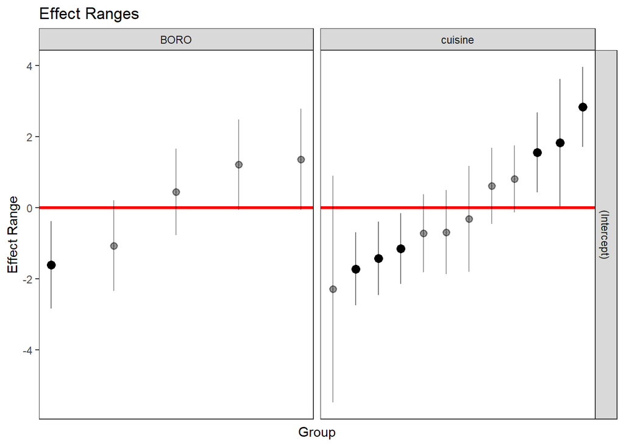

```r
plotREsim(REsim(clusterMod))
```

We should also see if our predictions improved:

```r
clusterPredict = predict(clusterMod)

head(cbind(actual = healthData$SCORE,
           clustered = clusterPredict,
           mixed = mixedPred,
           slim = slimPred), 20)
```

```
   actual clustered    mixed     slim
1      18  19.28713 21.40671 20.67657
2      39  19.44896 21.33549 21.00055
3      12  20.07550 21.38798 20.28845
4      28  20.17598 21.34376 20.48960
5      10  23.67651 21.28248 21.24163
6       4  19.47156 21.32554 21.04579
7       9  17.25207 19.45224 20.67354
8      18  24.36511 21.68792 21.12855
9      25  20.32682 21.65763 21.26634
10     19  22.06295 20.17974 20.97907
11      7  17.88168 20.21237 20.83064
12     17  21.14971 20.10837 21.30368
13     10  21.93627 20.12837 21.21274
14      9  22.18274 20.12701 21.21891
15     38  22.03625 20.19149 20.92563
16     19  24.36684 21.68716 21.13201
17     11  20.31816 21.66144 21.24901
18     11  25.39586 21.70010 21.07315
19     18  20.30999 21.66504 21.23266
20     17  19.45647 21.33218 21.01559
```

For many observations, our predictions definitely go tighter (many are still far off, though).

If we continue to look at our data (and with some knowledge about how NYC does health inspections), we will see that restaurants are rated yearly – let’s use this information in our model. We won’t worry about distance anymore, because now we have a few competing hypotheses. We could imagine two different ways that the works: one in which a restuarant’s score improves as observations increase (it takes some time for the owner to get his staff fully up to speed) or one in which the score decreases as the observations increase (the “shine has worn off the penny”).

Let’s do a bit of data processing first.

```r
healthDataGrouped = healthData %>%
  tidyr::unite(col = nameLocation, DBA, BUILDING , remove = FALSE) %>%
  group_by(nameLocation) %>%
  arrange(lubridate::mdy(`GRADE DATE`)) %>%
  mutate(observation = 1:n())

timeReviewed = healthDataGrouped %>%
  summarize(n = n()) %>%
  filter(n > 10)

reviewedRest = healthDataGrouped[which(healthDataGrouped$nameLocation %in%
                                         timeReviewed$nameLocation), ]
```

```r
observationMod = lmer(SCORE ~ observation + (1|nameLocation), data = reviewedRest)
```

In this model, we have a fixed effect for observation and we are allowing each location to have it’s own random intercept. We have essentially created a model that will deal with the repeated measures for each of the locations.

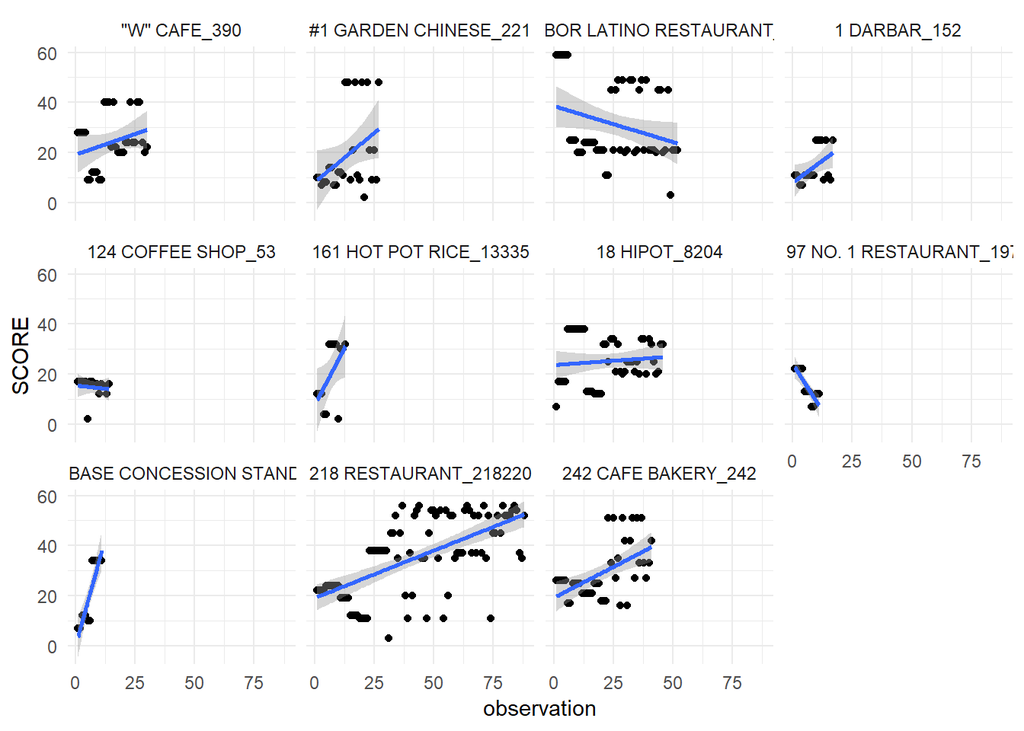

```r
reviewedRest %>%
  arrange(nameLocation, observation) %>%
  head(., 350) %>%
  ggplot(., aes(observation, SCORE, group = nameLocation)) +
  geom_point() +
  geom_smooth(method = "lm") +
  facet_wrap( ~ nameLocation) +
  theme_minimal()
```

```r
summary(observationMod)
```

```
Linear mixed model fit by REML ['lmerMod']
Formula: SCORE ~ observation + (1 | nameLocation)
   Data: reviewedRest

REML criterion at convergence: 345661

Scaled residuals:
    Min      1Q  Median      3Q     Max
-5.0067 -0.5765 -0.1311  0.4606  6.6361

Random effects:
 Groups       Name        Variance Std.Dev.
 nameLocation (Intercept)  29.46    5.428
 Residual                 125.82   11.217
Number of obs: 44622, groups:  nameLocation, 1750

Fixed effects:
             Estimate Std. Error t value
(Intercept) 13.948018   0.159359   87.53
observation  0.461932   0.005331   86.65

Correlation of Fixed Effects:
            (Intr)
observation -0.455
```

Our fixed effect here would indicate that we have a slight increase in scores as our observations increase, but we can also see that scores will bounce around about 5 points on average by location alone.

```r
29.46 / (29.46 + 125.82)
```

```
[1] 0.1897218
```

We see that the location alone accounts for nearly 20% of the variance in health scores.

## Hierarchical Models

Hierarchical models are a slight variation on the models that we have just seen. In these models, we have groups nested within other groups. We know that we have a “BORO” variable, but a quick look at our data will show that we also have a DBA variable; this variable is giving the name of the restaurant. One source of inquiry would be to inspect how various chain restaurants, nested within each boro, perform.

Let’s check out how some chain restaurants do within the boroughs.

```r
chainFood = healthDataGrouped %>%
  filter(DBA == "BURGER KING" |
           DBA == "MCDONALD'S" |
           DBA == "PIZZA HUT" |
           DBA == "SUBWAY")
```

The model set-up is just different enough to cause some potential confusion here. Within the parentheses, we have our intercept as before, but we are also saying that we are looking at the DBA groups within the BORO groups.

```r
hierMod = lme4::lmer(SCORE ~ observation + (1|BORO/DBA),
                     data = chainFood)

summary(hierMod)
```

```
Linear mixed model fit by REML ['lmerMod']
Formula: SCORE ~ observation + (1 | BORO/DBA)
   Data: chainFood

REML criterion at convergence: 1317.5

Scaled residuals:
    Min      1Q  Median      3Q     Max
-1.9087 -0.5211 -0.1990  0.1679  3.7629

Random effects:
 Groups   Name        Variance Std.Dev.
 DBA:BORO (Intercept)  11.076   3.328
 BORO     (Intercept)   1.877   1.370
 Residual             168.917  12.997
Number of obs: 165, groups:  DBA:BORO, 9; BORO, 5

Fixed effects:
            Estimate Std. Error t value
(Intercept)   7.5428     2.2741   3.317
observation   1.2320     0.2306   5.342

Correlation of Fixed Effects:
            (Intr)
observation -0.609
```

We have our fixed effect for observation (indicating that there is a positive relationship between observations and scores) and we have individual intercepts for both BORO and DBA nested within BORO. Looking at the standard deviation of our random effects, we can see that the scores bounce around a little over 3 points from chain to chain. If we explore the variance components, we see that around 6% (11.076 / (11.076 + 1.877 + 168.91)) of the variance in score is handled within our nested random effect.

We can also look at our effect ranges:

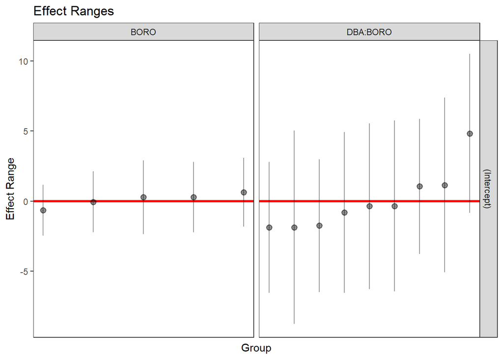

```r
plotREsim(REsim(hierMod))
```

Even though it does not look like there is too much going on in the way of effects here, we still need to know the group(s) that each dot represent(s):

```r
unique(hierMod@flist$BORO)
```

```
[1] QUEENS        BROOKLYN      MANHATTAN     STATEN ISLAND BRONX
Levels: BRONX BROOKLYN MANHATTAN QUEENS STATEN ISLAND
```

```r
unique(hierMod@flist$`DBA:BORO`)
```

```
[1] MCDONALD'S:QUEENS        SUBWAY:BROOKLYN
[3] MCDONALD'S:MANHATTAN     PIZZA HUT:MANHATTAN
[5] MCDONALD'S:BROOKLYN      PIZZA HUT:QUEENS
[7] MCDONALD'S:STATEN ISLAND BURGER KING:BROOKLYN
[9] MCDONALD'S:BRONX
9 Levels: BURGER KING:BROOKLYN MCDONALD'S:BRONX ... SUBWAY:BROOKLYN
```

They appear in the same order in the graph as they do printed out, so we can just map them on. While the interval is large and certainly crosses 0, it seems like the effect for McDonald’s in the Bronx is sizeable.

## Random Slopes

Now that we have seen random intercepts and hierarchical models, we can add one final piece: random slopes. In the following model, we will specify a random intercept (recall, it is the 1 within our parenthesis) and a random slope (we are putting the prefixing our grouping variable with a slope of interest). Not only will this model allow the intercept to vary between groups, but it will also allow the slope to vary between groups.

```r
observationMod = lmer(SCORE ~ observation + (1 + observation|nameLocation), data = reviewedRest)

summary(observationMod)
```

```
Linear mixed model fit by REML ['lmerMod']
Formula: SCORE ~ observation + (1 + observation | nameLocation)
   Data: reviewedRest

REML criterion at convergence: 342130.5

Scaled residuals:
    Min      1Q  Median      3Q     Max
-5.3899 -0.5413 -0.0949  0.4448  7.6038

Random effects:
 Groups       Name        Variance Std.Dev. Corr
 nameLocation (Intercept)  40.3173  6.3496
              observation   0.2546  0.5046  -0.56
 Residual                 109.6194 10.4699
Number of obs: 44622, groups:  nameLocation, 1750

Fixed effects:
            Estimate Std. Error t value
(Intercept) 12.42496    0.18418   67.46
observation  0.63182    0.01486   42.51

Correlation of Fixed Effects:
            (Intr)
observation -0.648
convergence code: 0
Model is nearly unidentifiable: very large eigenvalue
 - Rescale variables?
```

If we use the predicted values of our model, we can see what our results will look like over the observations:

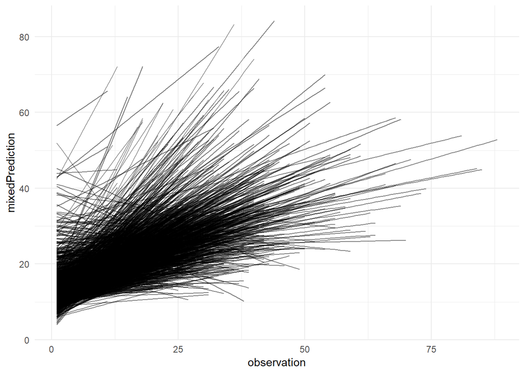

```r
randEffPlot = reviewedRest %>%
  ungroup() %>%
  mutate(mixedPrediction = predict(observationMod)) %>%
  group_by(nameLocation) %>%
  ggplot(., aes(observation, mixedPrediction, group = nameLocation)) +
  geom_line(alpha = .5) +
  theme_minimal()

randEffPlot
```

For the sake of demonstration, and hopefully as a way to bring everyting together, let’s see what predictions from a standard regression might look like compared to our mixed model:

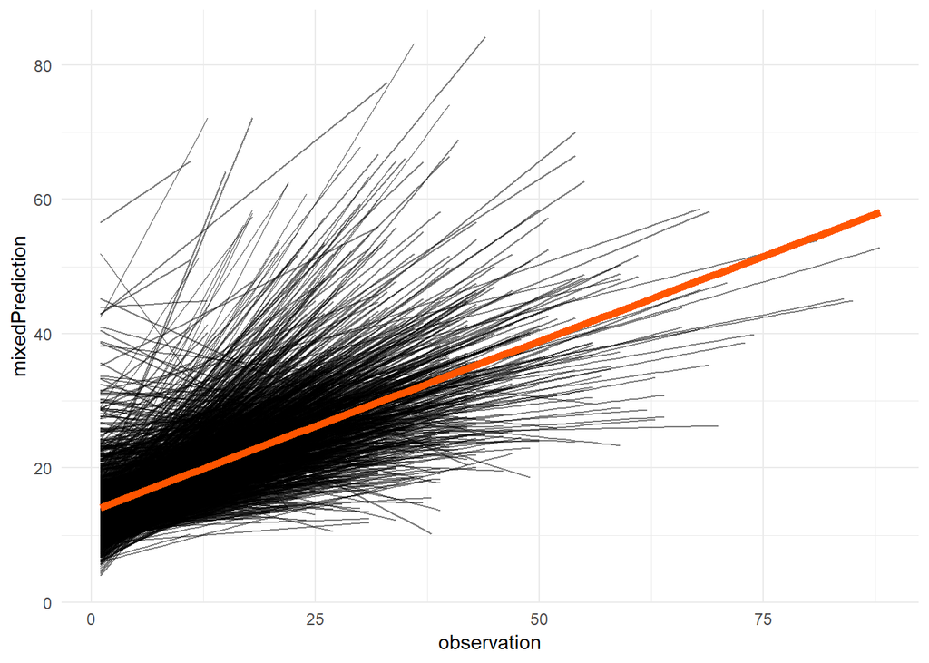

```r
slimPred = predict(lm(SCORE ~ observation, data = reviewedRest))

reviewedRest = reviewedRest %>%
  ungroup() %>%
  mutate(slimPrediction = slimPred)

randEffPlot +
  geom_line(data = reviewedRest, aes(observation, slimPrediction),
            color = "#ff5500", size = 2)
```

It looks like the standard regression line would do okay for many of our locations, but we can see that it would do poorly with many others. This should help to provide an illustration of just how flexible and powerful mixed model can be in your hands.